# R Notebook TP 1: Análisis Exploratorio e Introducción a Regresión lineal

Gustavo Arturo Ríos Páez

05 de Octubre de 2020

CONSIGNAS El objetivo general es poder crear un modelo lineal simple para explicar el precio de venta de las propiedades en Capital Federal reportadas por la empresa Properati. Para ello es necesario realizar analisis exploratorios, limpieza del dataset y realizar los modelos. Vamos a utilizar datos del 2019 para no incorporar comportamientos atípicos ocasionados por la pandemia del COVID-19.

```r
#Añado librerías necesarias
library(tidyverse)
library(corrr)
#library(tidymodels)
```

1. Preparación de los datos (I) a.Leer el archivo ar_properties.csv y mostrar su estructura

```r
#Leo los datos del dataSet
datos_propiedades <- read.csv("ar_properties.csv")
```

```r
#Revisión datos con str
str(datos_propiedades)
```

```
'data.frame':   388891 obs. of  24 variables:
 $ id             : chr  "S0we3z3V2JpHUJreqQ2t/w==" "kMxcmAS8NvrynGBVbMOEaQ==" "Ce3ojF+ZTOkB8d+LI9dpxg==" "AUGpj3raGmOCiulSMGIBPA==" ...
 $ ad_type        : chr  "Propiedad" "Propiedad" "Propiedad" "Propiedad" ...
 $ start_date     : chr  "2019-04-14" "2019-04-14" "2019-04-14" "2019-04-14" ...
 $ end_date       : chr  "2019-06-14" "2019-04-16" "9999-12-31" "9999-12-31" ...
 $ created_on     : chr  "2019-04-14" "2019-04-14" "2019-04-14" "2019-04-14" ...
 $ lat            : num  -34.9 -34.6 NA -34.7 -34.7 ...
 $ lon            : num  -54.9 -58.4 NA -58.8 -58.8 ...
 $ l1             : chr  "Uruguay" "Argentina" "Argentina" "Argentina" ...
 $ l2             : chr  "Maldonado" "Capital Federal" "Bs.As. G.B.A. Zona Norte" "Bs.As. G.B.A. Zona Oeste" ...
 $ l3             : chr  "Punta del Este" "Boedo" NA "Moreno" ...
 $ l4             : chr  NA NA NA "Moreno" ...
 $ l5             : chr  NA NA NA NA ...
 $ l6             : logi  NA NA NA NA NA NA ...
 $ rooms          : int  2 NA 2 2 2 4 NA 6 NA NA ...
 $ bedrooms       : int  NA NA NA NA NA NA NA NA NA NA ...
 $ bathrooms      : int  1 NA 1 2 3 1 3 3 NA NA ...
 $ surface_total  : int  45 NA 200 460 660 NA 70 NA 1300 405 ...
 $ surface_covered: int  40 NA NA 100 148 89 122 NA NA NA ...
 $ price          : int  13000 0 NA NA NA NA NA NA 0 NA ...
 $ currency       : chr  "UYU" NA NA NA ...
 $ price_period   : chr  "Mensual" "Mensual" NA "Mensual" ...
 $ title          : chr  "Departamento - Roosevelt" "PH - Boedo" "Ituzaingo  1100 - $ 1 - Casa Alquiler" "Dr. Vera   300 - Consulte precio - Casa en Venta" ...
 $ property_type  : chr  "Departamento" "PH" "Casa" "Casa" ...
 $ operation_type : chr  "Alquiler" "Venta" "Alquiler" "Venta" ...
```

```r
#Revisión datos con Glipse
glimpse(datos_propiedades)
```

```
Rows: 388,891
Columns: 24
$ id              <chr> "S0we3z3V2JpHUJreqQ2t/w==", "kMxcmAS8NvrynGBVbMOEaQ==", "Ce3ojF+ZTOkB8d+LI9dpxg==", "AUGpj3raGmOCiulSMGIBP…
$ ad_type         <chr> "Propiedad", "Propiedad", "Propiedad", "Propiedad", "Propiedad", "Propiedad", "Propiedad", "Propiedad", "P…
$ start_date      <chr> "2019-04-14", "2019-04-14", "2019-04-14", "2019-04-14", "2019-04-14", "2019-04-14", "2019-04-14", "2019-04…
$ end_date        <chr> "2019-06-14", "2019-04-16", "9999-12-31", "9999-12-31", "2019-07-09", "2019-08-08", "2019-07-10", "2019-06…
$ created_on      <chr> "2019-04-14", "2019-04-14", "2019-04-14", "2019-04-14", "2019-04-14", "2019-04-14", "2019-04-14", "2019-04…
$ lat             <dbl> -34.94331, -34.63181, NA, -34.65471, -34.65495, -32.93547, -34.65183, -34.91213, -34.60338, NA, -34.59005,…
$ lon             <dbl> -54.92966, -58.42060, NA, -58.79089, -58.78712, -60.68398, -58.65912, -54.84749, -58.43450, NA, -58.43672,…
$ l1              <chr> "Uruguay", "Argentina", "Argentina", "Argentina", "Argentina", "Argentina", "Argentina", "Uruguay", "Argen…
$ l2              <chr> "Maldonado", "Capital Federal", "Bs.As. G.B.A. Zona Norte", "Bs.As. G.B.A. Zona Oeste", "Bs.As. G.B.A. Zon…
$ l3              <chr> "Punta del Este", "Boedo", NA, "Moreno", "Moreno", "Rosario", "Ituzaingó", "José Ignacio", "Almagro", "Mir…
$ l4              <chr> NA, NA, NA, "Moreno", "Moreno", NA, "Ituzaingó", NA, NA, NA, NA, NA, NA, NA, NA, NA, NA, NA, NA, NA, NA, N…
$ l5              <chr> NA, NA, NA, NA, NA, NA, NA, NA, NA, NA, NA, NA, NA, NA, NA, NA, NA, NA, NA, NA, NA, NA, NA, NA, NA, NA, NA…
$ l6              <lgl> NA, NA, NA, NA, NA, NA, NA, NA, NA, NA, NA, NA, NA, NA, NA, NA, NA, NA, NA, NA, NA, NA, NA, NA, NA, NA, NA…
$ rooms           <int> 2, NA, 2, 2, 2, 4, NA, 6, NA, NA, NA, NA, NA, NA, NA, NA, NA, NA, NA, NA, 1, 1, 1, 1, 1, 1, 1, 1, 1, 1, 1,…
$ bedrooms        <int> NA, NA, NA, NA, NA, NA, NA, NA, NA, NA, NA, NA, NA, NA, NA, NA, NA, NA, NA, NA, NA, NA, NA, NA, NA, NA, NA…
$ bathrooms       <int> 1, NA, 1, 2, 3, 1, 3, 3, NA, NA, NA, NA, NA, NA, NA, NA, NA, NA, 1, NA, 1, 1, 1, 1, 1, 1, 1, 1, 1, 1, 1, 1…
$ surface_total   <int> 45, NA, 200, 460, 660, NA, 70, NA, 1300, 405, 352, 373, 360, 1325, 250, 80142, 101, NA, 54, 180, 36, 36, 4…
$ surface_covered <int> 40, NA, NA, 100, 148, 89, 122, NA, NA, NA, NA, NA, NA, 2, NA, NA, NA, NA, 54, 180, 33, 33, 34, 34, 34, 34,…
$ price           <int> 13000, 0, NA, NA, NA, NA, NA, NA, 0, NA, 0, NA, NA, NA, NA, NA, 0, 0, 0, NA, 0, 0, 0, 0, 0, 0, 0, 0, 0, 0,…
$ currency        <chr> "UYU", NA, NA, NA, NA, NA, NA, NA, NA, NA, NA, NA, NA, NA, NA, NA, NA, NA, NA, NA, NA, NA, NA, NA, NA, NA,…
$ price_period    <chr> "Mensual", "Mensual", NA, "Mensual", "Mensual", "Mensual", "Mensual", "Mensual", "Mensual", "Mensual", "Me…
$ title           <chr> "Departamento - Roosevelt", "PH - Boedo", "Ituzaingo  1100 - $ 1 - Casa Alquiler", "Dr. Vera   300 - Consu…
$ property_type   <chr> "Departamento", "PH", "Casa", "Casa", "Casa", "Casa", "Casa", "Casa", "Lote", "Lote", "Lote", "Lote", "Lot…
$ operation_type  <chr> "Alquiler", "Venta", "Alquiler", "Venta", "Venta", "Venta", "Venta", "Alquiler", "Venta", "Venta", "Venta"…
```

```r
#Clase de los datos
class(datos_propiedades) #DataFrame
```

```
[1] "data.frame"
```

Se observa que el dataframe está compeusto por 388,891 observaciones caracterizadas por 24 variables. 15 Variables de tipo caracter 8 Variables de tipo numérico 1 Variable de tipo lógico

Estas variables podrían agruparse tambíen del siguiente modo: 3 variables de fecha. 8 Variables describiendo la ubicación, dos de ellas de latitud y longitud, y 6 de ellas variables de texto describiendo ubicación desde país yendo a mayor detalle por ciudad, barrio, etc. 5 Variables descriptivas de la propiedad. 7 Variables descriptivas del condiciones de venta o arrendamiento. 1 Variable ID.

b.Quedarse con aquellos registros que: I.Pertenecen a Argentina y Capital Federal

```r
datos_propiedades_filter <- datos_propiedades %>%
  filter(l1 == "Argentina" , l2 == "Capital Federal")
datos_propiedades_filter
```

| id | ad_type | start_date | end_date | created_on | lat | lon | l1 | l2 | l3 | l4 | l5 | l6 | rooms | bedrooms | bathrooms | surface_total | surface_covered | price | currency | price_period | title | property_type | operation_type |
| --- | --- | --- | --- | --- | --- | --- | --- | --- | --- | --- | --- | --- | --- | --- | --- | --- | --- | --- | --- | --- | --- | --- | --- |
| kMxcmAS8NvrynGBVbMOEaQ== | Propiedad | 2019-04-14 | 2019-04-16 | 2019-04-14 | -34.63181 | -58.42060 | Argentina | Capital Federal | Boedo | NA | NA | NA | NA | NA | NA | NA | NA | 0 | NA | Mensual | PH - Boedo | PH | Venta |
| zOYqfAgKkdKypVwwfTBFYw== | Propiedad | 2019-04-14 | 2019-04-29 | 2019-04-14 | -34.60338 | -58.43450 | Argentina | Capital Federal | Almagro | NA | NA | NA | NA | NA | NA | 1300 | NA | 0 | NA | Mensual | Terreno de 1 ambiente en Venta en Almagro | Lote | Venta |
| fXgtUB5rLqkreIOoWrZGkg== | Propiedad | 2019-04-14 | 2019-04-29 | 2019-04-14 | -34.59005 | -58.43672 | Argentina | Capital Federal | Palermo | NA | NA | NA | NA | NA | NA | 352 | NA | 0 | NA | Mensual | Terreno de 1 ambiente en Venta en Palermo | Lote | Venta |
| mcLRAPUcifz7ySBjD2n1Dw== | Propiedad | 2019-04-14 | 2019-04-29 | 2019-04-14 | -34.59413 | -58.44373 | Argentina | Capital Federal | Villa Crespo | NA | NA | NA | NA | NA | NA | 101 | NA | 0 | NA | Mensual | Terreno de 1 ambiente en Venta en Villa crespo | Lote | Venta |
| lEweB+LK19AbVSlIkSfXOA== | Propiedad | 2019-04-14 | 2019-04-29 | 2019-04-14 | -34.60483 | -58.41904 | Argentina | Capital Federal | Almagro | NA | NA | NA | NA | NA | 1 | 54 | 54 | 0 | NA | Mensual | Oficina de 1 ambiente en Venta en Almagro | Oficina | Venta |
| QL6ZPnzQXqV3+5ZonqkCVA== | Propiedad | 2019-04-14 | 9999-12-31 | 2019-04-14 | -34.60370 | -58.38347 | Argentina | Capital Federal | San Nicolás | NA | NA | NA | NA | NA | NA | 180 | 180 | NA | NA | Mensual | Oficina - San Nicolas | Oficina | Alquiler |
| phTTlD76IMd0kefXQehyFw== | Propiedad | 2019-04-14 | 2019-04-29 | 2019-04-14 | -34.58977 | -58.42073 | Argentina | Capital Federal | Palermo | NA | NA | NA | 1 | NA | 1 | 36 | 33 | 0 | NA | Mensual | Departamento de 1 ambiente en Venta en Palermo | Departamento | Venta |
| rwPWPvpeqZ2OZqxSQhvUiw== | Propiedad | 2019-04-14 | 2019-04-29 | 2019-04-14 | -34.58977 | -58.42073 | Argentina | Capital Federal | Palermo | NA | NA | NA | 1 | NA | 1 | 36 | 33 | 0 | NA | Mensual | Departamento de 1 ambiente en Venta en Palermo | Departamento | Venta |
| vyT5ISRfXujZJPp9rQuv6g== | Propiedad | 2019-04-14 | 2019-04-29 | 2019-04-14 | -34.58977 | -58.42073 | Argentina | Capital Federal | Palermo | NA | NA | NA | 1 | NA | 1 | 40 | 34 | 0 | NA | Mensual | Departamento de 1 ambiente en Venta en Palermo | Departamento | Venta |
| dCuGX6XrqNnlzpi94Bf0LA== | Propiedad | 2019-04-14 | 2019-04-29 | 2019-04-14 | -34.58977 | -58.42073 | Argentina | Capital Federal | Palermo | NA | NA | NA | 1 | NA | 1 | 43 | 34 | 0 | NA | Mensual | Departamento de 1 ambiente en Venta en Palermo | Departamento | Venta |

[output cut: 990 more lines]

Aplicando este primer filtro por País y ciudad, tenemos ahora 124.327 propiedades.

II.Cuyo precio esta en dólares (USD)

```r
datos_propiedades_filter <- datos_propiedades_filter %>%
  filter(currency == "USD")
datos_propiedades_filter
```

| id | ad_type | start_date | end_date | created_on | lat | lon | l1 | l2 | l3 | l4 | l5 | l6 | rooms | bedrooms | bathrooms | surface_total | surface_covered | price | currency | price_period | title | property_type | operation_type |
| --- | --- | --- | --- | --- | --- | --- | --- | --- | --- | --- | --- | --- | --- | --- | --- | --- | --- | --- | --- | --- | --- | --- | --- |
| lnQPuBQdzGwJ9akSrlt18Q== | Propiedad | 2019-04-14 | 2019-06-23 | 2019-04-14 | -34.59773 | -58.38025 | Argentina | Capital Federal | Retiro | NA | NA | NA | NA | NA | NA | 13 | NA | 22000 | USD | NA | VENTA - COCHERA - RETIRO | Cochera | Venta |
| 4XQ+AhiGd1fjqaMBs7wKJQ== | Propiedad | 2019-04-14 | 2019-04-17 | 2019-04-14 | -34.59924 | -58.42652 | Argentina | Capital Federal | Almagro | NA | NA | NA | NA | NA | NA | NA | NA | 22000 | USD | Mensual | COCHERA EN VENTA | Cochera | Venta |
| sPaaKKHnzVV2hllqm7LHIA== | Propiedad | 2019-04-14 | 2019-06-23 | 2019-04-14 | -34.59205 | -58.38857 | Argentina | Capital Federal | Recoleta | NA | NA | NA | NA | NA | NA | 26 | NA | 45500 | USD | NA | Cochera DOBLE de 26 m2 totales en RECOLETA | Cochera | Venta |
| 2Onpsu8EJMq1OIYuguv9+Q== | Propiedad | 2019-04-14 | 2019-08-17 | 2019-04-14 | -34.59964 | -58.39053 | Argentina | Capital Federal | Barrio Norte | NA | NA | NA | NA | NA | NA | NA | 9 | 23500 | USD | NA | COCHERA EN AV. CORDOBA 1500 | Cochera | Venta |
| BZR4Z16so70uY4h7R8dbpg== | Propiedad | 2019-04-14 | 2019-06-23 | 2019-04-14 | -34.59251 | -58.38909 | Argentina | Capital Federal | Barrio Norte | NA | NA | NA | NA | NA | NA | 26 | NA | 45500 | USD | NA | Cochera DOBLE de 26 m2 totales en Barrio Norte | Cochera | Venta |
| FAxYJtLAKtgVrIFfweCuoQ== | Propiedad | 2019-04-14 | 2019-06-23 | 2019-04-14 | -34.58002 | -58.49026 | Argentina | Capital Federal | Villa Urquiza | NA | NA | NA | NA | NA | NA | NA | NA | 44000 | USD | NA | Cochera Doble en SS (ideal inversor) acceso por rampa, coche mediano, grande o camioneta. Seg. 24hs. | Cochera | Venta |
| Z81OFuXsde81Zn2u8ft2cg== | Propiedad | 2019-04-14 | 2019-04-29 | 2019-04-14 | -34.63184 | -58.39794 | Argentina | Capital Federal | Parque Patricios | NA | NA | NA | NA | NA | NA | 3586 | 3586 | 2600000 | USD | Mensual | Galpon de 1 ambiente en Venta en Parque patricios | Depósito | Venta |
| Fg7ZNV99KX/x8uJ7DSPTQw== | Propiedad | 2019-04-14 | 9999-12-31 | 2019-04-14 | -34.57671 | -58.40295 | Argentina | Capital Federal | Palermo | Palermo Chico | NA | NA | 3 | NA | NA | 75 | 60 | 1500 | USD | Mensual | Ph alquiler | PH | Alquiler |
| oyj+f764ALCYodIqBvWAww== | Propiedad | 2019-04-14 | 2019-07-10 | 2019-04-14 | -34.65225 | -58.38556 | Argentina | Capital Federal | Barracas | NA | NA | NA | NA | NA | NA | 300 | 180 | 320000 | USD | Mensual | PH EN VENTA | PH | Venta |
| HdjpKrqdwYfH9YU1DKjltg== | Propiedad | 2019-04-14 | 2019-04-15 | 2019-04-14 | -34.62825 | -58.40652 | Argentina | Capital Federal | Boedo | NA | NA | NA | 6 | NA | 2 | 178 | 240 | 500000 | USD | Mensual | Casa - San Telmo | Casa | Venta |

[output cut: 990 more lines]

Aplicando este segundo filtro tenemos 81.601 propiedades.

III.El tipo de propiedad sea: Departamento, PH o Casa

```r
#datos_propiedades_filter %>%
#  filter(property_type == "Departamento" | property_type == "PH" | property_type == "Casa")
#De forma más limpia:
datos_propiedades_filter <- datos_propiedades_filter %>%
  filter(property_type %in% c("Departamento", "PH", "Casa"))
datos_propiedades_filter
```

| id | ad_type | start_date | end_date | created_on | lat | lon | l1 | l2 | l3 | l4 | l5 | l6 | rooms | bedrooms | bathrooms | surface_total | surface_covered | price | currency | price_period | title | property_type | operation_type |
| --- | --- | --- | --- | --- | --- | --- | --- | --- | --- | --- | --- | --- | --- | --- | --- | --- | --- | --- | --- | --- | --- | --- | --- |
| Fg7ZNV99KX/x8uJ7DSPTQw== | Propiedad | 2019-04-14 | 9999-12-31 | 2019-04-14 | -34.57671 | -58.40295 | Argentina | Capital Federal | Palermo | Palermo Chico | NA | NA | 3 | NA | NA | 75 | 60 | 1500 | USD | Mensual | Ph alquiler | PH | Alquiler |
| oyj+f764ALCYodIqBvWAww== | Propiedad | 2019-04-14 | 2019-07-10 | 2019-04-14 | -34.65225 | -58.38556 | Argentina | Capital Federal | Barracas | NA | NA | NA | NA | NA | NA | 300 | 180 | 320000 | USD | Mensual | PH EN VENTA | PH | Venta |
| HdjpKrqdwYfH9YU1DKjltg== | Propiedad | 2019-04-14 | 2019-04-15 | 2019-04-14 | -34.62825 | -58.40652 | Argentina | Capital Federal | Boedo | NA | NA | NA | 6 | NA | 2 | 178 | 240 | 500000 | USD | Mensual | Casa - San Telmo | Casa | Venta |
| YwWE3rTb2+gmsBwjUHmAPQ== | Propiedad | 2019-04-14 | 2019-06-30 | 2019-04-14 | -34.59280 | -58.42093 | Argentina | Capital Federal | Palermo | NA | NA | NA | NA | NA | 2 | 240 | 157 | 350000 | USD | Mensual | CASA EN VENTA | Casa | Venta |
| 6AxnSWOhbIU8TUCqb+paBg== | Propiedad | 2019-04-14 | 9999-12-31 | 2019-04-14 | -34.56563 | -58.46513 | Argentina | Capital Federal | Belgrano | NA | NA | NA | 3 | NA | 4 | 157 | NA | 470000 | USD | NA | Mendoza 3200 - U$D 470.000 - Casa en Venta | Casa | Venta |
| U4fk+co3Rd8JDMot0pQI6Q== | Propiedad | 2019-04-14 | 2019-05-21 | 2019-04-14 | -34.62218 | -58.52272 | Argentina | Capital Federal | Versalles | NA | NA | NA | NA | NA | 1 | 140 | 110 | 155000 | USD | NA | Cortina 2000 - U$D 155.000 - Tipo casa PH en Venta | Casa | Venta |
| AfdcsqUSelai1ofCAq2B0Q== | Propiedad | 2019-04-14 | 9999-12-31 | 2019-04-14 | -34.63210 | -58.49768 | Argentina | Capital Federal | Velez Sarsfield | NA | NA | NA | 3 | NA | 2 | 95 | 69 | 199900 | USD | NA | Moron 4800 - U$D 199.900 - Tipo casa PH en Venta | Casa | Venta |
| ESzybdH7YU2uIU1/kHtRGw== | Propiedad | 2019-04-14 | 9999-12-31 | 2019-04-14 | -34.54307 | -58.46259 | Argentina | Capital Federal | Nuñez | NA | NA | NA | 1 | NA | 1 | 44 | 38 | 147000 | USD | Mensual | OPORTUNIDAD! Edificio de Categoría! 1 Amb y 1/2. 44mts2. Entrega Septiembre 2019!!- Nuñez | Departamento | Venta |
| r22OfzZ3kXooSPoE5HMuZQ== | Propiedad | 2019-04-14 | 2019-04-29 | 2019-04-14 | -34.60152 | -58.42435 | Argentina | Capital Federal | Almagro | NA | NA | NA | 1 | NA | 1 | 40 | 37 | 92294 | USD | Mensual | Departamento de 1 ambiente en Venta en Almagro | Departamento | Venta |
| atZQXVtyfG7+OiX6gYY3lA== | Propiedad | 2019-04-14 | 2019-04-29 | 2019-04-14 | -34.60152 | -58.42435 | Argentina | Capital Federal | Almagro | NA | NA | NA | 1 | NA | 1 | 49 | 44 | 115000 | USD | Mensual | Departamento de 1 ambiente en Venta en Almagro | Departamento | Venta |

[output cut: 990 more lines]

```r
#Departamento -> 57.712
#PH -> 5.851
#Casa -> 3.807
```

IV.El tipo de operacion sea Venta

```r
datos_propiedades_filter <- datos_propiedades_filter %>%
  filter(operation_type == "Venta")
datos_propiedades_filter
```

| id | ad_type | start_date | end_date | created_on | lat | lon | l1 | l2 | l3 | l4 | l5 | l6 | rooms | bedrooms | bathrooms | surface_total | surface_covered | price | currency | price_period | title | property_type | operation_type |
| --- | --- | --- | --- | --- | --- | --- | --- | --- | --- | --- | --- | --- | --- | --- | --- | --- | --- | --- | --- | --- | --- | --- | --- |
| oyj+f764ALCYodIqBvWAww== | Propiedad | 2019-04-14 | 2019-07-10 | 2019-04-14 | -34.65225 | -58.38556 | Argentina | Capital Federal | Barracas | NA | NA | NA | NA | NA | NA | 300 | 180 | 320000 | USD | Mensual | PH EN VENTA | PH | Venta |
| HdjpKrqdwYfH9YU1DKjltg== | Propiedad | 2019-04-14 | 2019-04-15 | 2019-04-14 | -34.62825 | -58.40652 | Argentina | Capital Federal | Boedo | NA | NA | NA | 6 | NA | 2 | 178 | 240 | 500000 | USD | Mensual | Casa - San Telmo | Casa | Venta |
| YwWE3rTb2+gmsBwjUHmAPQ== | Propiedad | 2019-04-14 | 2019-06-30 | 2019-04-14 | -34.59280 | -58.42093 | Argentina | Capital Federal | Palermo | NA | NA | NA | NA | NA | 2 | 240 | 157 | 350000 | USD | Mensual | CASA EN VENTA | Casa | Venta |
| 6AxnSWOhbIU8TUCqb+paBg== | Propiedad | 2019-04-14 | 9999-12-31 | 2019-04-14 | -34.56563 | -58.46513 | Argentina | Capital Federal | Belgrano | NA | NA | NA | 3 | NA | 4 | 157 | NA | 470000 | USD | NA | Mendoza 3200 - U$D 470.000 - Casa en Venta | Casa | Venta |
| U4fk+co3Rd8JDMot0pQI6Q== | Propiedad | 2019-04-14 | 2019-05-21 | 2019-04-14 | -34.62218 | -58.52272 | Argentina | Capital Federal | Versalles | NA | NA | NA | NA | NA | 1 | 140 | 110 | 155000 | USD | NA | Cortina 2000 - U$D 155.000 - Tipo casa PH en Venta | Casa | Venta |
| AfdcsqUSelai1ofCAq2B0Q== | Propiedad | 2019-04-14 | 9999-12-31 | 2019-04-14 | -34.63210 | -58.49768 | Argentina | Capital Federal | Velez Sarsfield | NA | NA | NA | 3 | NA | 2 | 95 | 69 | 199900 | USD | NA | Moron 4800 - U$D 199.900 - Tipo casa PH en Venta | Casa | Venta |
| ESzybdH7YU2uIU1/kHtRGw== | Propiedad | 2019-04-14 | 9999-12-31 | 2019-04-14 | -34.54307 | -58.46259 | Argentina | Capital Federal | Nuñez | NA | NA | NA | 1 | NA | 1 | 44 | 38 | 147000 | USD | Mensual | OPORTUNIDAD! Edificio de Categoría! 1 Amb y 1/2. 44mts2. Entrega Septiembre 2019!!- Nuñez | Departamento | Venta |
| r22OfzZ3kXooSPoE5HMuZQ== | Propiedad | 2019-04-14 | 2019-04-29 | 2019-04-14 | -34.60152 | -58.42435 | Argentina | Capital Federal | Almagro | NA | NA | NA | 1 | NA | 1 | 40 | 37 | 92294 | USD | Mensual | Departamento de 1 ambiente en Venta en Almagro | Departamento | Venta |
| atZQXVtyfG7+OiX6gYY3lA== | Propiedad | 2019-04-14 | 2019-04-29 | 2019-04-14 | -34.60152 | -58.42435 | Argentina | Capital Federal | Almagro | NA | NA | NA | 1 | NA | 1 | 49 | 44 | 115000 | USD | Mensual | Departamento de 1 ambiente en Venta en Almagro | Departamento | Venta |
| R7IsTtVsxPCiRbIHMaWGxA== | Propiedad | 2019-04-14 | 2019-04-29 | 2019-04-14 | -34.60152 | -58.42435 | Argentina | Capital Federal | Almagro | NA | NA | NA | 1 | NA | 1 | 40 | 37 | 77000 | USD | Mensual | Departamento de 1 ambiente en Venta en Almagro | Departamento | Venta |

[output cut: 990 more lines]

Con el filtro de tipo de venta tendríamos un total de 61.905 observaciones.

c.Seleccionar las variables id, l3, rooms, bedrooms, bathrooms, surface_total, surface_covered, price y property_type.

```r
datos_propiedades_filter <- datos_propiedades_filter %>%
  select(id, l3, rooms, bedrooms, bathrooms, surface_total, surface_covered, price, property_type)
datos_propiedades_filter
```

| id | l3 | rooms | bedrooms | bathrooms | surface_total | surface_covered | price | property_type |
| --- | --- | --- | --- | --- | --- | --- | --- | --- |
| oyj+f764ALCYodIqBvWAww== | Barracas | NA | NA | NA | 300 | 180 | 320000 | PH |
| HdjpKrqdwYfH9YU1DKjltg== | Boedo | 6 | NA | 2 | 178 | 240 | 500000 | Casa |
| YwWE3rTb2+gmsBwjUHmAPQ== | Palermo | NA | NA | 2 | 240 | 157 | 350000 | Casa |
| 6AxnSWOhbIU8TUCqb+paBg== | Belgrano | 3 | NA | 4 | 157 | NA | 470000 | Casa |
| U4fk+co3Rd8JDMot0pQI6Q== | Versalles | NA | NA | 1 | 140 | 110 | 155000 | Casa |
| AfdcsqUSelai1ofCAq2B0Q== | Velez Sarsfield | 3 | NA | 2 | 95 | 69 | 199900 | Casa |
| ESzybdH7YU2uIU1/kHtRGw== | Nuñez | 1 | NA | 1 | 44 | 38 | 147000 | Departamento |
| r22OfzZ3kXooSPoE5HMuZQ== | Almagro | 1 | NA | 1 | 40 | 37 | 92294 | Departamento |
| atZQXVtyfG7+OiX6gYY3lA== | Almagro | 1 | NA | 1 | 49 | 44 | 115000 | Departamento |
| R7IsTtVsxPCiRbIHMaWGxA== | Almagro | 1 | NA | 1 | 40 | 37 | 77000 | Departamento |

[output cut: 990 more lines]

#Deberian llegar a un dataset con 61.905 observaciones y 9 variables.

2.Análisis exploratorios (I) a.Obtener la cantidad de valores únicos y de valores faltantes (NAs) para cada una de estas variables.

Podríamos usar n_distinct para evaluar NA por cada variable, por ejemplo:

```r
n_distinct(datos_propiedades_filter$l3)
```

```
[1] 58
```

Pero con sapply podemos obtener los NA para todo el dataset de forma más sencilla

```r
sapply(datos_propiedades_filter, function(x) sum(is.na(x)))
```

```
             id              l3           rooms        bedrooms       bathrooms   surface_total surface_covered           price
              0             355            5314           25298            3196            3671            2975               0
  property_type
              0
```

Y también los valores únicos

```r
sapply(datos_propiedades_filter, function(x) n_distinct(x))
```

```
             id              l3           rooms        bedrooms       bathrooms   surface_total surface_covered           price
          61905              58              24              25              15             671             573            4095
  property_type
              3
```

La función summary también nos sirve para validar los NAs

```r
summary(datos_propiedades_filter)
```

```
      id                 l3                rooms          bedrooms         bathrooms      surface_total      surface_covered
 Length:61905       Length:61905       Min.   : 1.00   Min.   :  0.000   Min.   : 1.000   Min.   :     0.0   Min.   :     0.00
 Class :character   Class :character   1st Qu.: 2.00   1st Qu.:  1.000   1st Qu.: 1.000   1st Qu.:    45.0   1st Qu.:    40.00
 Mode  :character   Mode  :character   Median : 3.00   Median :  2.000   Median : 1.000   Median :    66.0   Median :    59.00
                                       Mean   : 2.79   Mean   :  2.052   Mean   : 1.517   Mean   :   103.9   Mean   :    87.06
                                       3rd Qu.: 4.00   3rd Qu.:  3.000   3rd Qu.: 2.000   3rd Qu.:   107.0   3rd Qu.:    93.00
                                       Max.   :32.00   Max.   :130.000   Max.   :14.000   Max.   :126062.0   Max.   :126062.00
                                       NA's   :5314    NA's   :25298     NA's   :3196     NA's   :3671       NA's   :2975
     price          property_type
 Min.   :    6000   Length:61905
 1st Qu.:  115200   Class :character
 Median :  169000   Mode  :character
 Mean   :  257556
 3rd Qu.:  273000
 Max.   :45535353
```

En general se ve alrededor de un 5% faltante de datos, a exepción de la variable bedrooms que presenta un 41% de datos faltantes.

b.Obtener la matriz de correlaciones para las variables numéricas. Pista: usen ‘complete.obs’ para poder omitir los valores faltantes.

Calculando por el método de Pearson (y filtrando las variables numéricas con select) obtemnemos:

```r
correlated_pearson <- cor(datos_propiedades_filter %>%
  select(-id, -l3, -property_type)
    , use="complete.obs", method="pearson") %>%
  correlate() %>% #Para convertir la matrix en un data frame
  shave() %>% #Para mostrar sólo lo que está abajo de la diagonal
  fashion() #Para redondear decimales y hacerlo más legible
```

```
Correlation method: 'pearson'
Missing treated using: 'pairwise.complete.obs'
```

```r
correlated_pearson
```

| rowname | rooms | bedrooms | bathrooms | surface_total | surface_covered | price |
| --- | --- | --- | --- | --- | --- | --- |
| rooms |  |  |  |  |  |  |
| bedrooms | .99 |  |  |  |  |  |
| bathrooms | .73 | .72 |  |  |  |  |
| surface_total | -.85 | -.83 | -.89 |  |  |  |
| surface_covered | -.85 | -.83 | -.88 | .89 |  |  |
| price | .50 | .45 | .73 | -.82 | -.81 |  |

Observamos algunas correlacionesmarcadas y esperadas, como bedrooms<->rooms ,rooms<->bathrooms y surface_total<->surface_covered. Vemos también una correlación alta entre una variable de las que más nos interesan price<->bathrooms.

Sin embargo, vemos algunas correlaciones negativas que llaman mucho la atención: rooms<->surface_total rooms<->surface_covered price<->surface_total price<->surface_covered Esto parecería contradecir la lógica, dado que esperaríamos que una casa de mayor área cuente con mayor cantidad de habitaciones, además de con un precio mayor, lo que en ambos casos implicaría correlaciones positivas.

Teniendo en cuenta que el calculo de correlación bajo el método Pearson es bastante sensible a outliers realizamos una nueva matriz de correlación con el método Spearman que es más robusto.

```r
correlated_spearman <- cor(datos_propiedades_filter %>%
  select(-id, -l3, -property_type)
    , use="complete.obs", method="spearman") %>%
  correlate() %>% #Para convertir la matrix en un data frame
  shave() %>% #Para mostrar sólo lo que está abajo de la diagonal
  fashion() #Para redondear decimales y hacerlo más legible
```

```
Correlation method: 'pearson'
Missing treated using: 'pairwise.complete.obs'
```

```r
correlated_spearman
```

| rowname | rooms | bedrooms | bathrooms | surface_total | surface_covered | price |
| --- | --- | --- | --- | --- | --- | --- |
| rooms |  |  |  |  |  |  |
| bedrooms | .99 |  |  |  |  |  |
| bathrooms | -.81 | -.78 |  |  |  |  |
| surface_total | .42 | .35 | -.64 |  |  |  |
| surface_covered | .54 | .48 | -.69 | .96 |  |  |
| price | -.40 | -.46 | -.19 | .43 | .34 |  |

Efectivamente vemos que la correlaciones: rooms<->surface_total rooms<->surface_covered price<->surface_total price<->surface_covered Que nos llamaban la atención para a ser positivas, y además vemos muy marcada la correlación surface_total<->surface_covered.

c.Grafique la matriz de correlaciones usando la librería corrr.

De forma gráfica tenemos bajo el método Pearson:

```
Correlation method: 'pearson'
Missing treated using: 'pairwise.complete.obs'
```

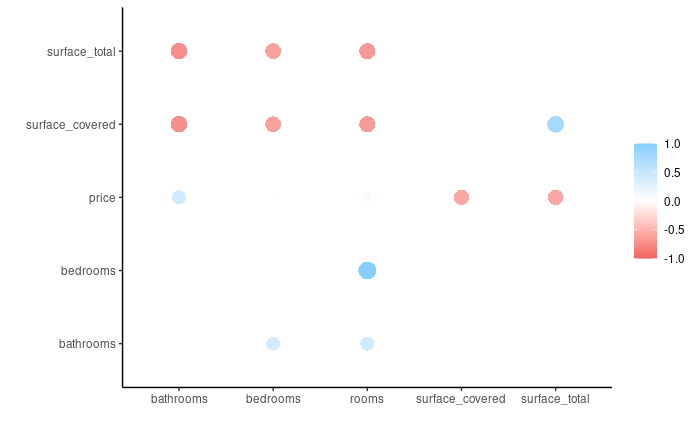

```r
cor(datos_propiedades_filter %>%
  select(-id, -l3, -property_type)
    , use="complete.obs", method="pearson") %>%
  correlate() %>% #Para convertir la matrix en un data frame
  shave() %>% #Para mostrar sólo lo que está abajo de la diagonal
  rplot() #Graficamos
```

De forma gráfica tenemos bajo el método Spearman:

```
Correlation method: 'pearson'
Missing treated using: 'pairwise.complete.obs'
```

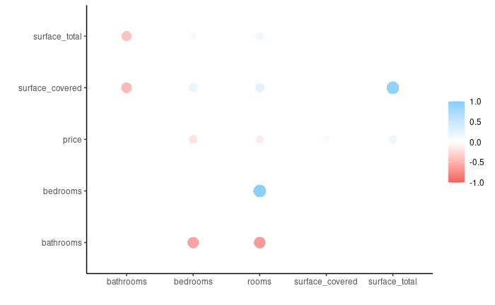

```r
cor(datos_propiedades_filter %>%
  select(-id, -l3, -property_type)
    , use="complete.obs", method="spearman") %>%
  correlate() %>% #Para convertir la matrix en un data frame
  shave() %>% #Para mostrar sólo lo que está abajo de la diagonal
  rplot() #Graficamos
```

También si queremos clasificar por tipo de propiedad:

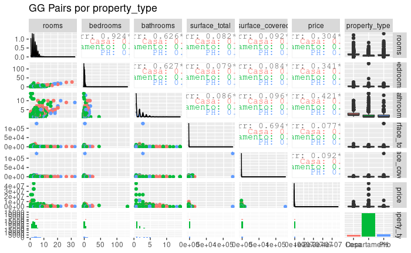

```r
datos_propiedades_filter %>%
  select(-id,-l3,) %>% # desestimamos algunas variables
  mutate(property_type = factor(property_type)) %>%
  ggpairs(.,
        title = "GG Pairs por property_type",
        mapping = aes(colour = property_type))
```

d.¿Cómo es la correlación entre las variables surface_total y surface_covered? ¿Y la correlación entre rooms y bathrooms?

Graficamos las variables surface_total y surface_covered

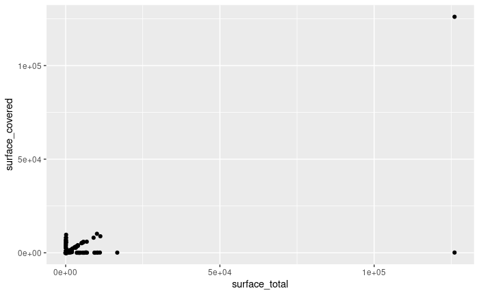

Se realizan los test análisis de correlación: Para el método Pearson

```r
cor.test(datos_propiedades_filter$surface_total, datos_propiedades_filter$surface_covered, method = "pearson")
```

```
    Pearson's product-moment correlation

data:  datos_propiedades_filter$surface_total and datos_propiedades_filter$surface_covered
t = 229.8, df = 56704, p-value < 2.2e-16
alternative hypothesis: true correlation is not equal to 0
95 percent confidence interval:
 0.6901322 0.6986559
sample estimates:
      cor
0.6944184
```

Vemos un p-valor bastante pequeño que nos da la suficiente evidencia muestral para descartar la hipótesis nula, el coeficiente de correlación es 0.69

Ahora con el método Spearman:

```r
cor.test(datos_propiedades_filter$surface_total, datos_propiedades_filter$surface_covered, method = "spearman")
```

```
Cannot compute exact p-value with ties
```

```
    Spearman's rank correlation rho

data:  datos_propiedades_filter$surface_total and datos_propiedades_filter$surface_covered
S = 1.1755e+12, p-value < 2.2e-16
alternative hypothesis: true rho is not equal to 0
sample estimates:
      rho
0.9613189
```

```r
cor.test(datos_propiedades_filter$surface_total, datos_propiedades_filter$surface_covered, method = "kendall")
```

```
    Kendall's rank correlation tau

data:  datos_propiedades_filter$surface_total and datos_propiedades_filter$surface_covered
z = 306.74, p-value < 2.2e-16
alternative hypothesis: true tau is not equal to 0
sample estimates:
      tau
0.8674506
```

Del mismo modo el p-valor es muy pequeño con lo que tenemos suficiente evidencia para descartar la hipótesis nula. Se observa una corelación marcada entre las dos variables.

Respecto a las variables rooms y bathrooms, estás se encuentran relacionadas de forma positiva para un análisis Pearson, sin embargo se ve una relación de relación fuerte negativa para Spearman.

Graficamos las variables rooms y bathrooms

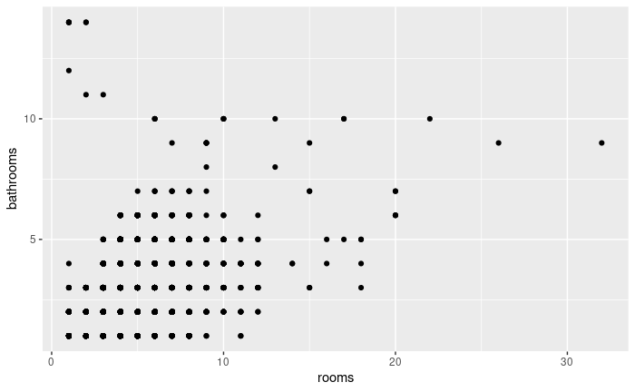

```r
ggplot(datos_propiedades_filter, aes(x = rooms, y = bathrooms)) +
  geom_point()
```

No pareciera tenerse una correlación lineal entre estas dos variables. Procedemos a hacer tests de correlación:

```r
cor.test(datos_propiedades_filter$rooms, datos_propiedades_filter$bathrooms, method = "pearson")
```

```
    Pearson's product-moment correlation

data:  datos_propiedades_filter$rooms and datos_propiedades_filter$bathrooms
t = 188.08, df = 54966, p-value < 2.2e-16
alternative hypothesis: true correlation is not equal to 0
95 percent confidence interval:
 0.6206331 0.6308063
sample estimates:
      cor
0.6257463
```

Ahora con el método Spearman:

```r
cor.test(datos_propiedades_filter$rooms, datos_propiedades_filter$bathrooms, method = "spearman")
```

```
Cannot compute exact p-value with ties
```

```
    Spearman's rank correlation rho

data:  datos_propiedades_filter$rooms and datos_propiedades_filter$bathrooms
S = 9.9471e+12, p-value < 2.2e-16
alternative hypothesis: true rho is not equal to 0
sample estimates:
      rho
0.6406495
```

```r
cor.test(datos_propiedades_filter$rooms, datos_propiedades_filter$bathrooms, method = "kendall")
```

```
    Kendall's rank correlation tau

data:  datos_propiedades_filter$rooms and datos_propiedades_filter$bathrooms
z = 154.39, p-value < 2.2e-16
alternative hypothesis: true tau is not equal to 0
sample estimates:
      tau
0.5701826
```

En ninguno de los dos casos observamos una correlación fuerte.

e.¿Cómo es la correlación de la variable a explicar, price, con el resto de las variables?

```r
correlated_pearson
```

| rowname | rooms | bedrooms | bathrooms | surface_total | surface_covered | price |
| --- | --- | --- | --- | --- | --- | --- |
| rooms |  |  |  |  |  |  |
| bedrooms | .99 |  |  |  |  |  |
| bathrooms | .73 | .72 |  |  |  |  |
| surface_total | -.85 | -.83 | -.89 |  |  |  |
| surface_covered | -.85 | -.83 | -.88 | .89 |  |  |
| price | .50 | .45 | .73 | -.82 | -.81 |  |

Para el método Pearson está relacionada con bathrooms de forma positiva, de la correlación negativa con surface_total y surface_covered ya hablamos.

```r
correlated_spearman
```

| rowname | rooms | bedrooms | bathrooms | surface_total | surface_covered | price |
| --- | --- | --- | --- | --- | --- | --- |
| rooms |  |  |  |  |  |  |
| bedrooms | .99 |  |  |  |  |  |
| bathrooms | -.81 | -.78 |  |  |  |  |
| surface_total | .42 | .35 | -.64 |  |  |  |
| surface_covered | .54 | .48 | -.69 | .96 |  |  |
| price | -.40 | -.46 | -.19 | .43 | .34 |  |

Para un análisis con método Spearman vemos una relación algo débil con surface_total y con surface_covered,se ve también una corelación negativa frente a bedrooms que llama la atención.

3.Limpieza de datos a.En el punto 2 deberían haber encontrado que la variable bedrooms presenta una alta proporción de valores faltantes y que presenta una fuerte correlación con la variable rooms. Por lo tanto, vamos a eliminarla.

```r
datos_propiedades_filter2 <- datos_propiedades_filter %>% select(-bedrooms)
datos_propiedades_filter2
```

| id | l3 | rooms | bathrooms | surface_total | surface_covered | price | property_type |
| --- | --- | --- | --- | --- | --- | --- | --- |
| oyj+f764ALCYodIqBvWAww== | Barracas | NA | NA | 300 | 180 | 320000 | PH |
| HdjpKrqdwYfH9YU1DKjltg== | Boedo | 6 | 2 | 178 | 240 | 500000 | Casa |
| YwWE3rTb2+gmsBwjUHmAPQ== | Palermo | NA | 2 | 240 | 157 | 350000 | Casa |
| 6AxnSWOhbIU8TUCqb+paBg== | Belgrano | 3 | 4 | 157 | NA | 470000 | Casa |
| U4fk+co3Rd8JDMot0pQI6Q== | Versalles | NA | 1 | 140 | 110 | 155000 | Casa |
| AfdcsqUSelai1ofCAq2B0Q== | Velez Sarsfield | 3 | 2 | 95 | 69 | 199900 | Casa |
| ESzybdH7YU2uIU1/kHtRGw== | Nuñez | 1 | 1 | 44 | 38 | 147000 | Departamento |
| r22OfzZ3kXooSPoE5HMuZQ== | Almagro | 1 | 1 | 40 | 37 | 92294 | Departamento |
| atZQXVtyfG7+OiX6gYY3lA== | Almagro | 1 | 1 | 49 | 44 | 115000 | Departamento |
| R7IsTtVsxPCiRbIHMaWGxA== | Almagro | 1 | 1 | 40 | 37 | 77000 | Departamento |

[output cut: 990 more lines]

b.Eliminar todos los registros que presentan valores faltantes.

```r
datos_propiedades_filter2 <- drop_na(datos_propiedades_filter2)
datos_propiedades_filter2 <- datos_propiedades_filter2 %>% filter(surface_total >= surface_covered)
datos_propiedades_filter2
```

| id | l3 | rooms | bathrooms | surface_total | surface_covered | price | property_type |
| --- | --- | --- | --- | --- | --- | --- | --- |
| AfdcsqUSelai1ofCAq2B0Q== | Velez Sarsfield | 3 | 2 | 95 | 69 | 199900 | Casa |
| ESzybdH7YU2uIU1/kHtRGw== | Nuñez | 1 | 1 | 44 | 38 | 147000 | Departamento |
| r22OfzZ3kXooSPoE5HMuZQ== | Almagro | 1 | 1 | 40 | 37 | 92294 | Departamento |
| atZQXVtyfG7+OiX6gYY3lA== | Almagro | 1 | 1 | 49 | 44 | 115000 | Departamento |
| R7IsTtVsxPCiRbIHMaWGxA== | Almagro | 1 | 1 | 40 | 37 | 77000 | Departamento |
| Tur/v/qE41UBT83NM/bI7w== | Almagro | 1 | 1 | 40 | 37 | 88900 | Departamento |
| PNtNl6sWjHEyRPQAeRAIgw== | Almagro | 1 | 1 | 40 | 37 | 88798 | Departamento |
| Lhg4dNG9VmPbHt0Swy2ATA== | Almagro | 1 | 1 | 49 | 44 | 110975 | Departamento |
| MFngc+8f1sFriO+lteUuZw== | Almagro | 1 | 1 | 40 | 37 | 92943 | Departamento |
| mVq2X1mkiRWN9A34SR7AoA== | Almagro | 1 | 1 | 23 | 23 | 69000 | Departamento |

[output cut: 990 more lines]

c.Eliminar aquellos registros en los cuales la superficie total es menor a la superficie cubierta

#Deberían llegar a un dataset con 50.828 observaciones y 8 variables.

4.Análisis exploratorios (II) a.Crear una nueva variable precio_en_miles que sea la variable price divida por 1000. Obtener estadísticas descriptivas para esta nueva variable (cuartiles, promedio, mínimo y máximo) y realizar un histograma de la misma.

```r
datos_propiedades_filter2$precio_en_miles <- (datos_propiedades_filter2$price)/1000
datos_propiedades_filter2
```

| id | l3 | rooms | bathrooms | surface_total | surface_covered | price | property_type | precio_en_miles |
| --- | --- | --- | --- | --- | --- | --- | --- | --- |
| AfdcsqUSelai1ofCAq2B0Q== | Velez Sarsfield | 3 | 2 | 95 | 69 | 199900 | Casa | 199.900 |
| ESzybdH7YU2uIU1/kHtRGw== | Nuñez | 1 | 1 | 44 | 38 | 147000 | Departamento | 147.000 |
| r22OfzZ3kXooSPoE5HMuZQ== | Almagro | 1 | 1 | 40 | 37 | 92294 | Departamento | 92.294 |
| atZQXVtyfG7+OiX6gYY3lA== | Almagro | 1 | 1 | 49 | 44 | 115000 | Departamento | 115.000 |
| R7IsTtVsxPCiRbIHMaWGxA== | Almagro | 1 | 1 | 40 | 37 | 77000 | Departamento | 77.000 |
| Tur/v/qE41UBT83NM/bI7w== | Almagro | 1 | 1 | 40 | 37 | 88900 | Departamento | 88.900 |
| PNtNl6sWjHEyRPQAeRAIgw== | Almagro | 1 | 1 | 40 | 37 | 88798 | Departamento | 88.798 |
| Lhg4dNG9VmPbHt0Swy2ATA== | Almagro | 1 | 1 | 49 | 44 | 110975 | Departamento | 110.975 |
| MFngc+8f1sFriO+lteUuZw== | Almagro | 1 | 1 | 40 | 37 | 92943 | Departamento | 92.943 |
| mVq2X1mkiRWN9A34SR7AoA== | Almagro | 1 | 1 | 23 | 23 | 69000 | Departamento | 69.000 |

[output cut: 990 more lines]

```r
summary(datos_propiedades_filter2$precio_en_miles)
```

```
   Min. 1st Qu.  Median    Mean 3rd Qu.    Max.
    6.0   119.0   170.0   251.6   270.0  6000.0
```

Acorde a los cuantiles no veriamos una variabilidad excesiva, el valor máximo parece bastante extremo.

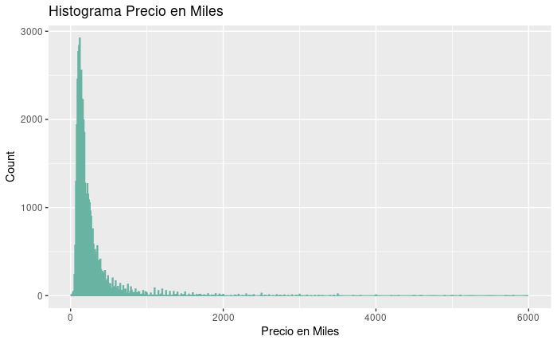

```r
#qplot(datos_propiedades_filter2$precio_en_miles, geom = "histogram")
ggplot(data=datos_propiedades_filter2, aes(precio_en_miles)) +
  geom_histogram(breaks=seq(6, 6000, by=10),
                 #fill="red",
                 color="#69b3a2",
                 alpha = .2) +
  labs(title="Histograma Precio en Miles", x="Precio en Miles", y="Count")
```

El histograma revela una moda bastante marcada, y un outlier realmente alto. Graficamos con un límite diferente para ignorar el outlier

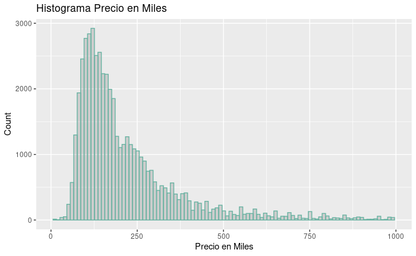

```r
#qplot(datos_propiedades_filter2$precio_en_miles, geom = "histogram")
ggplot(data=datos_propiedades_filter2, aes(precio_en_miles)) +
  geom_histogram(breaks=seq(6, 1000, by=10),
                 #fill="red",
                 color="#69b3a2",
                 alpha = .2) +
  labs(title="Histograma Precio en Miles", x="Precio en Miles", y="Count")
```

b.Obtener las mismas estadísticas descriptivas de la nueva variable precio_en_miles para cada tipo de propiedad y realizar boxplots paralelos de la variable según tipo de propiedad. ¿Qué diferencias encuentran entre los tipos de propiedad?

Utilizaremos tapply con la función summary para esto:

```r
tapply(datos_propiedades_filter2$precio_en_miles, datos_propiedades_filter2$property_type, summary)
```

```
$Casa
   Min. 1st Qu.  Median    Mean 3rd Qu.    Max.
   20.0   235.0   330.0   433.4   490.0  5000.0

$Departamento
   Min. 1st Qu.  Median    Mean 3rd Qu.    Max.
    6.0   115.0   164.9   247.4   260.0  6000.0

$PH
   Min. 1st Qu.  Median    Mean 3rd Qu.    Max.
   32.0   137.0   190.0   218.5   270.0  1500.0
```

Observamos outliers notables en las casas y los apartamentos, en los PHs también tenemos ouliers pero en una menor magnitud.

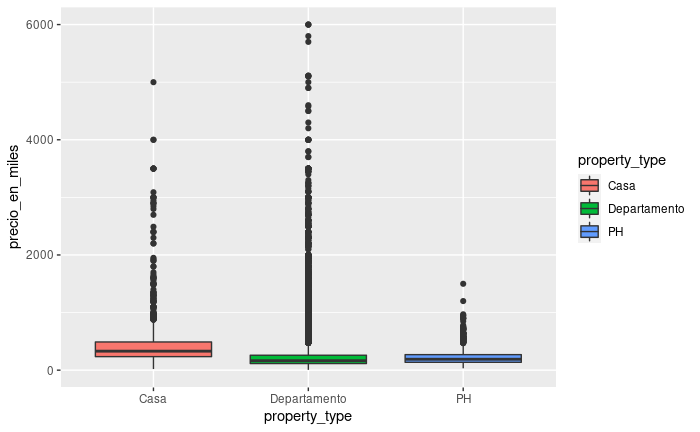

```r
ggplot(datos_propiedades_filter2, aes(x = property_type, y = precio_en_miles, group = property_type, fill = property_type))+
  geom_boxplot() +
  scale_y_continuous(limits = c(0, 6000)) # definimos escala del eje y
```

El tercer cuartil más 1.5 veces la distancia intercuartil nos da 496.5, esto dejaría algunos valores interesantes por fuera, tomaremos el valor de 1000 para voler a graficar. (Un poco menos que 5 distancias I.Q. adicionales).

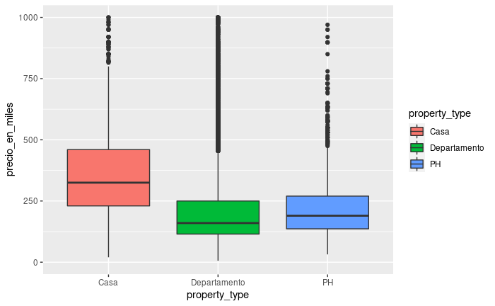

```r
ggplot(datos_propiedades_filter2, aes(x = property_type, y = precio_en_miles, group = property_type, fill = property_type))+
  geom_boxplot() +
  scale_y_continuous(limits = c(0, 1000)) # definimos escala del eje y
```

c.Realizar un gráfico con la función ggpairs de las variables numéricas (sin abrir por tipo de propiedad). Comenten los aspectos principales que observan en el gráfico

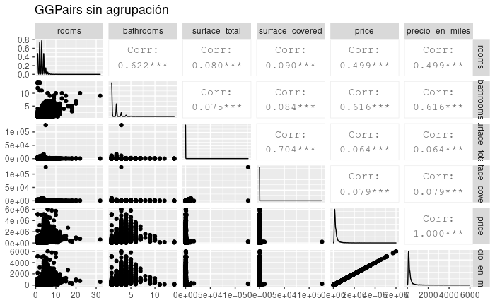

Se aprecia una relación entre el precio y la cantidad de habitaciones, incluso una mayor relación entre precio y cantidad de baños. Llama la atención la baja relación entre el precio y las variables de superficie, sin embargo las variables de superficie se ven también poco asociadas a la cantidad de habitaciones.

5.Outliers a.Graficar un scatterplot de la variable precio_en_miles y superficie_total. ¿Detectan alguna anomalía?

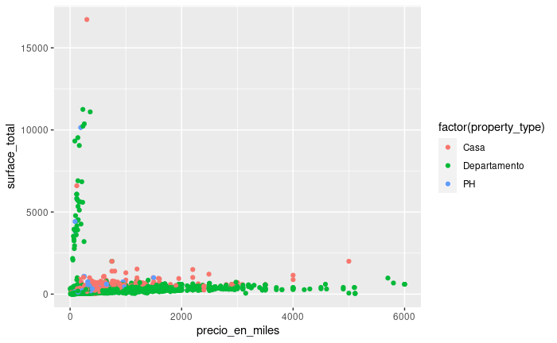

```r
ggplot(datos_propiedades_filter2, aes(x = precio_en_miles, y = surface_total)) +
  geom_point(alpha = 1/10) +
  geom_point(aes(colour = factor(property_type)))
```

Se tienen outliers de superficie muy marcados que no permiten observar claramente la información. Podría haber casos con información errónea respecto a la superficie. También pareciera haber algunos datos que guardan una relación lineal creciente entre las dos variables.

b.Eliminar los outliers univariados de las variables precio_en_miles, rooms y surface_total. Utilizar y fundamentar el o los criterio/s y métodos que consideren adecuados.

```r
(270+(270-251))*3
```

[output not shown]

```
[1] 867
```

Se toma como criterio eliminar outliers a más de 1.5 Distancias intercuartiles para el caso de rooms

```r
summary(datos_propiedades_filter2$rooms)
```

```
   Min. 1st Qu.  Median    Mean 3rd Qu.    Max.
  1.000   2.000   3.000   2.797   4.000  32.000
```

```r
#(4+(4-3))*1.5
#7.5
datos_propiedades_filter3 <- datos_propiedades_filter3 %>% filter(rooms < 7.5)
```

Se toma como criterio separar las propiedades de más de 500 metros y las de menos de 500. El criterio de distancia intercuartil no parecía apropiado, puesto que para 9 Di filtraba los menor a 200 metros, que es una medida esperada para una casa promedio.

```r
summary(datos_propiedades_filter2$surface_total)
```

```
   Min. 1st Qu.  Median    Mean 3rd Qu.    Max.
   12.0    45.0    66.0    96.8   106.0 16725.0
```

```r
#106+(106-96)*9
#196
datos_propiedades_filer_grandes <- datos_propiedades_filter3 %>% filter(surface_total > 500)
datos_propiedades_filter3 <- datos_propiedades_filter3 %>% filter(surface_total < 500)
```

Se grafica de nuevo el scatterplot para el dataset filtrado

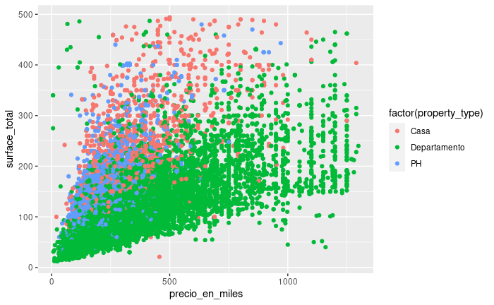

```r
ggplot(datos_propiedades_filter3, aes(x = precio_en_miles, y = surface_total)) +
  geom_point(alpha = 1/10) +
  geom_point(aes(colour = factor(property_type)))
```

6.Análisis exploratorios (III) Repetir los análisis exploratorios realizados en el punto 4 al dataset sin outliers. ¿Detectan algún cambio? Explicar. a.Obtener estadísticas descriptivas para la variable precio_en_miles (cuartiles, promedio, mínimo y máximo) y realizar un histograma de la misma.

```r
summary(datos_propiedades_filter3$precio_en_miles)
```

```
   Min. 1st Qu.  Median    Mean 3rd Qu.    Max.
    6.0   118.0   168.0   222.9   265.0  1299.0
```

La remoción de outliers no afectó en gran manera los estadísticos descriptivos de la variable precio en miles.

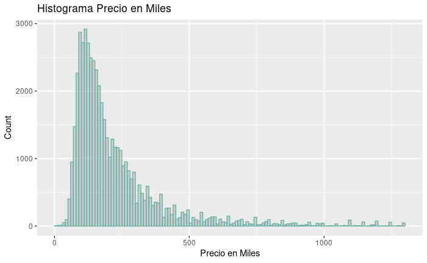

```r
#qplot(datos_propiedades_filter2$precio_en_miles, geom = "histogram")
ggplot(data=datos_propiedades_filter2, aes(precio_en_miles)) +
  geom_histogram(breaks=seq(0, 1300, by=10),
                 #fill="red",
                 color="#69b3a2",
                 alpha = .2) +
  labs(title="Histograma Precio en Miles", x="Precio en Miles", y="Count")
```

b.Obtener las mismas estadísticas descriptivas de la nueva variable precio_en_miles para cada tipo de propiedad y realizar boxplots paralelos de la variable según tipo de propiedad. ¿Qué diferencias encuentran entre los tipos de propiedad?

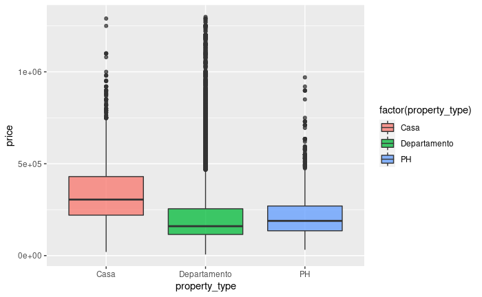

```r
ggplot(datos_propiedades_filter3, aes(property_type, price, group = property_type, fill = factor(property_type)))+
  geom_boxplot(alpha = 0.75)
```

Vemos una precios superiores en las casas en promedio frente a los departamentos y PHs (probablemente por la superficia de las mismas) Vemos una altísima variabilidad en los precios de los departamentos, podría explicarse por la variabilidad de su ubicación respecto a las diferentes zonas de la ciudad.

c.Realizar un gráfico con la función ggpairs de las variables numéricas (sin abrir por tipo de propiedad). Comenten los aspectos principales que observan en el gráfico

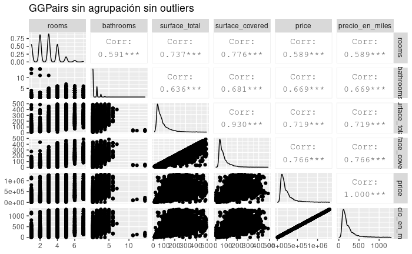

```r
datos_propiedades_filter3 %>%
  select(-id,-l3, -property_type) %>% # desestimamos algunas variables
  ggpairs(.,
        title = "GGPairs sin agrupación sin outliers")
```

Se ve una corelación marcada entre el precio y la superficie de las propiedades, sin embargo en la gráfica no se llega a ver relación lineal. En menor medida se observa también una corelación entre el precio y la cantidad de baños y habitaciones de la propiedad.

7.Modelo lineal a.Realizar un modelo lineal simple para explicar el precio_en_miles en función de las habitaciones (rooms) y otro modelo que explique el precio en función de la superficie total (surface_total).

```r
# Modelo Rooms
modelo_rooms = lm(formula = precio_en_miles ~ rooms, data = datos_propiedades_filter3)
#summary(modelo_rooms)
tidy(modelo_rooms)
```

| term | estimate | std.error | statistic | p.value |
| --- | --- | --- | --- | --- |
| (Intercept) | -0.1502225 | 1.5084303 | -0.09958863 | 0.9206713 |
| rooms | 82.1323238 | 0.5057364 | 162.40145862 | 0.0000000 |

```r
# Modelo Superficie Total
modelo_surface = lm(formula = precio_en_miles ~ surface_total, data = datos_propiedades_filter3)
#summary(modelo_surface)
tidy(modelo_surface)
```

| term | estimate | std.error | statistic | p.value |
| --- | --- | --- | --- | --- |
| (Intercept) | 53.269372 | 0.911454947 | 58.44433 | 0 |
| surface_total | 2.001306 | 0.008692158 | 230.24274 | 0 |

b.Usar la función summary() para obtener informacion de ambos modelos. Explicar el significado de los valores de los coeficientes estimados en cada caso.

```r
# Modelo Rooms
summary(modelo_rooms)
```

```
Call:
lm(formula = precio_en_miles ~ rooms, data = datos_propiedades_filter3)

Residuals:
    Min      1Q  Median      3Q     Max
-429.78  -75.11  -19.25   33.02 1078.02

Coefficients:
            Estimate Std. Error t value Pr(>|t|)
(Intercept)  -0.1502     1.5084    -0.1    0.921
rooms        82.1323     0.5057   162.4   <2e-16 ***
---
Signif. codes:  0 ‘***’ 0.001 ‘**’ 0.01 ‘*’ 0.05 ‘.’ 0.1 ‘ ’ 1

Residual standard error: 138.9 on 49618 degrees of freedom
Multiple R-squared:  0.3471,    Adjusted R-squared:  0.3471
F-statistic: 2.637e+04 on 1 and 49618 DF,  p-value: < 2.2e-16
```

Se tiene como intercepto con el eje y -0.150, el aumento por cada unidad de la variable habitación representa un aumento de 82k en el precio.

```r
# Modelo Superficie Total
summary(modelo_surface)
```

```
Call:
lm(formula = precio_en_miles ~ surface_total, data = datos_propiedades_filter3)

Residuals:
    Min      1Q  Median      3Q     Max
-949.00  -43.49  -17.42   22.56 1026.68

Coefficients:
               Estimate Std. Error t value Pr(>|t|)
(Intercept)   53.269372   0.911455   58.44   <2e-16 ***
surface_total  2.001306   0.008692  230.24   <2e-16 ***
---
Signif. codes:  0 ‘***’ 0.001 ‘**’ 0.01 ‘*’ 0.05 ‘.’ 0.1 ‘ ’ 1

Residual standard error: 119.5 on 49618 degrees of freedom
Multiple R-squared:  0.5165,    Adjusted R-squared:  0.5165
F-statistic: 5.301e+04 on 1 and 49618 DF,  p-value: < 2.2e-16
```

Se parte del intercepto en 53k por el aumento en superficia (1metro cuadrado) el valor de la propiedad aumenta en 2k.

c.¿Cuál modelo usarían para predecir el precio? ¿Por qué?

El modelo por habitaciones tiene un r-squared de 0.3471 lo que es menor al r-squared del modelo de superficie que es de 0.5165. El segundo modelo explica mejor la variabilidad de los datos, lo escogería. Sin embargo no descartaría el primero pues aporta entendimiento desde una variable importante al momento de elegir una casa.